# 02463 - Active Machine Learning and Agency

## Active machine learning - Uncertainty sampling

Kristoffer H. Madsen

Associate Professor

Senior Researcher

Section for Cognitive Systems

Computational Neuroimaging Group

Department of Applied Mathematics and computer Science

Danish Research Centre for Magnetic Resonance

Technical University of Denmark

Copenhagen University Hospital Hvidovre

khma@dtu.dk

kristofferm@drcmr.dk

[figure not shown]

# Ingredients

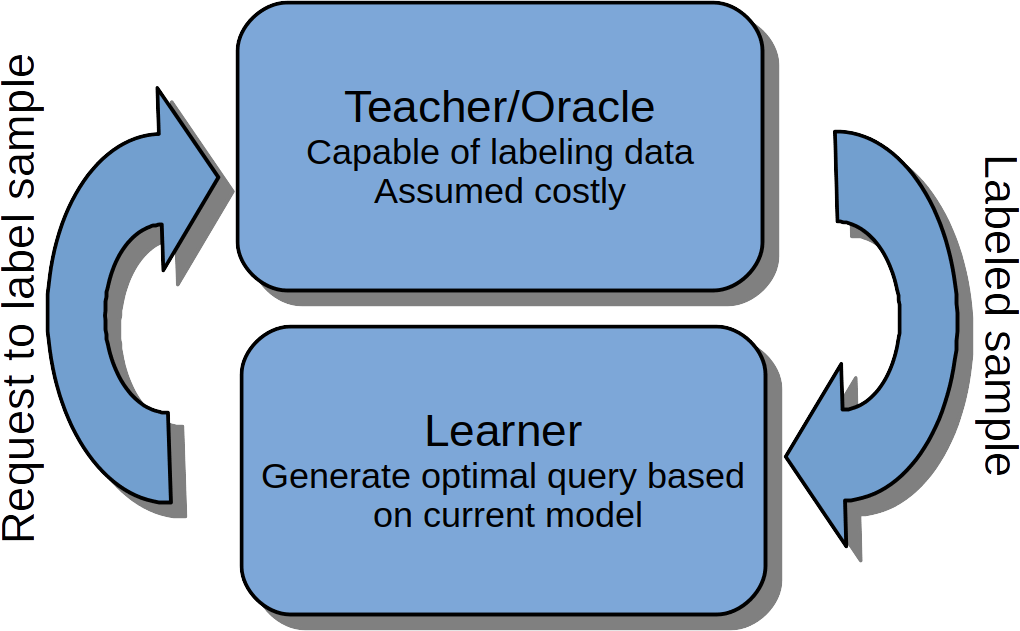

- Teacher / oracle (can give labels)
- Learner (selects which labels to obtain)
  - Uncertainty quantification
  - Again knowing how uncertain we are about the labels of data points (where we do not know the label) is key

# For categorical data

- One possibility would be to simply sample the point where the probability of the most likely label is smallest
  - Least confidence sampling: $$x^* = \underset{x \in U}{\text{argmax}} ~ (1 - p_\theta(\hat{y}_1 | x))$$
- Sample the point where the difference between the two most likely options is smallest
  - Margin sampling: $$x^* = \underset{x \in U}{\text{argmin}} ~ (p_\theta(\hat{y}_1 | x) - p_\theta(\hat{y}_2 | x))$$
- Sample the point with the largest entropy
  - Entropy sampling

# What is entropy?

## Information content

- Number of possible configurations
  - Say we assume that the prior possibility for rain is 50%.
  - That is there are two possible configurations for this variable either rain or no rain (with equal probability, and independent of other variables).
  - The total number of options quantifies uncertainty (freedom in the system)
  - If now someone says that it won't rain we reduce the number of options by half
  - In large systems the possible configurations become quite large, therefore using the logarithm of these options is more convenient
  - Also this log transformation ensures that if we get two independent pieces of information the information will be additive otherwise it would be multiplicative
- Information before:
  - $I=\operatorname{log}_2(2)=1$
- Information after:
  - $I=\operatorname{log}_2(1)=0$
- Change in information: 1 bit
- We can write this is terms of the probability distribution (where $N=\tfrac{1}{p(X=\operatorname{rain})}$): $$I(X=\operatorname{rain}) = \operatorname{log}_2\left(\frac{1}{P(\operatorname{X=rain})}\right)$$
- But this only considers one of the options so we can take the expectation over the possibilities $$H(X)=-\sum_x P(X=x)\operatorname{log}_2(P(x))=1$$
- Which gives us the typical definition of entropy (here measured in bits)

## What if you live in the dessert?

- Then apriori we would not expect rain say $P(X=\operatorname{rain}) = 0.01$
  - $H(x)=-0.01\operatorname{log}_2(0.01)-0.99\operatorname{log}_2(0.99)\approx0.08$
  - If someone where to tell os that it would rain, that would highly informative, otherwise (most of the times) the information gain is much less
  - On average we do not gain much information
- This readily generalizes to more options
  - In case of 8 options getting one label gets us $\operatorname{log}_2(8)=3$ bits of information
- And to cases where the label is noisy (here possibility for the remaining options will not be reduced to zero)

# Relative entropy

$$D_{\text{KL}}(P\mid\mid Q) = \sum_x P(x) \log \frac{P(x)}{Q(x)}$$

- Information gain obtained by updating the prior distribution $Q(x)$ to $P(x)$
- The change in information weighted by the probability represented in P(X)
- Non-symmetric (expectation is over P(x) exchanging to Q(x) will not always give the same result)

Select point with highest entropy: $$x^* = \underset{x \in U}{\text{argmax}} ~ -\sum_{y\in Y} p_\theta(y | x) \log p_\theta(y | x)$$

With binary labels these three strategies (least confident, largest margin, entropy) are equivalent (the log is a monotonic function)

# Two classes (binary)

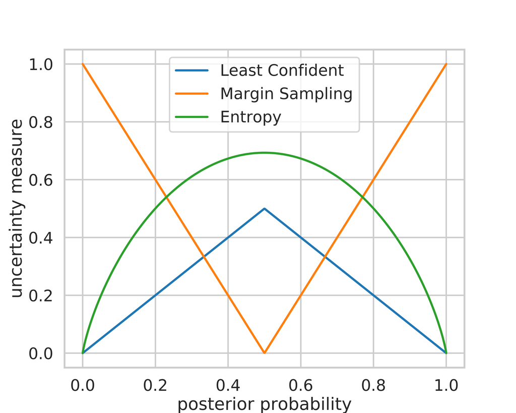

# Three classes (ternary)

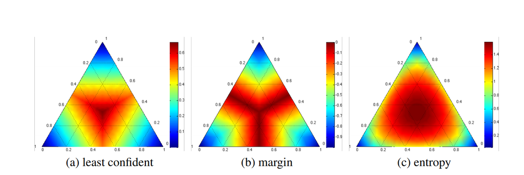

# Version space

- The set of models which are compatible with the currently sampled data
- To optimally learn model we wish to maximally reduce the version space
- For discrete and noiseless models the size version space can be measured as the number of models.
- When we consider non-discrete settings actually all models become somehow compatible with the data
- Then the size of the model space can be considered a probability weigthed volume